# Object Oriented Programming in Python

## Class methods (@classmethod Decorator)

Decorators are a very powerful and useful tool in Python since it allows programmers to **modify the behaviour of a function or class. Decorators allow us to wrap another function in order to extend the behaviour of the wrapped function, without permanently modifying it.** But before diving deep into decorators let us understand some concepts that will come in handy in learning the decorators.

**Decorator can modify the behaviour:**

```python
# A Python example to demonstrate that
# decorators can be useful attach data

# A decorator function to attach
# data to func
def attach_data(func):
    func.data = 3
    return func

@attach_data
def add (x, y):
       return x + y

# Driver code

# This call is equivalent to attach_data()
# with add() as parameter
print(add(2, 3))

print(add.data)
```

```
5
3
```

`add()` returns sum of x and y passed as arguments but it is wrapped by a decorator function, calling `add(2, 3)` would simply give sum of two numbers but when we call `add.data` then `add` function is passed into then decorator function `attach_data` as argument and this function returns `add` function with an attribute `data` that is set to 3 and hence prints it.

**Python decorators are a powerful tool to remove redundancy.**

```python
def my_decorator(func):
    def wrapper():
        print("Something is happening before the function is called.")
        func()
        print("Something is happening after the function is called.")
    return wrapper

@my_decorator
def say_whee():
    print("Whee!")
```

```python
say_whee()
```

```
Something is happening before the function is called.
Whee!
Something is happening after the function is called.
```

So, `@my_decorator`is just an easier way of saying `say_whee = my_decorator(say_whee)`. It’s how you apply a decorator to a function.

We can use decorator for Python class as well.

- `Classmethod` is sharing a function of class for every instance
- `Classmethod` can't use instance-level data

```python
class MyClass:
    @classmethod                      # a class method is declared by using decorator
    def my_awesome_method(cls, args): # cls argument refers to the class
        pass
        # No instance attribute can be used :(
```

**The `@classmethod` decorator is a built-in function decorator which is an expression that gets evaluated after your function is defined.** The result of that evaluation shadows your function definition.

A class method receives the class as the implicit first argument, just like an instance method receives the instance.

```python
# Python program to demonstrate
# use of a class method and static method.
from datetime import date

class Person:
    def __init__(self, name, age):
        self.name = name
        self.age = age

    # a class method to create a person object by birth year.
    @classmethod
    def fromBirthYear(cls, name, year):
        return cls(name, date.today().year - year) # return the object

person1 = Person('mayank', 21)
person2 = Person.fromBirthYear('mayank', 1980)

print(person1.age)
print(person2.age)
```

```
21
42
```

`@classmethod` Characteristics are:

- Declares a class method.
- The first parameter must be `cls`, which can be used to access class attributes.
- The class method can only access the class attributes but not the instance attributes.
- It can return an object of the class.

```python
class Student:
    name = 'unknown' # class attribute
    def __init__(self):
        self.age = 20  # instance attribute

    @classmethod
    def tostring(cls):
        print('Student Class Attributes: name=',cls.name)
```

```python
Student.tostring()
```

```
Student Class Attributes: name= unknown
```

For the above code, the `Student` class contains a class attribute `name` and an instance attribute `age`. The `tostring()` method is decorated with the `@classmethod` decorator that makes it a class method.

## Alternative Constructors

- **We can only have one `__init__`**

```python
class Staff:
    income_min = 40000
    def __init__(self, name, salary=40000):
        self.name = name
        if salary >= Staff.income_min:
            self.salary = salary
        else:
            self.salary = Staff.income_min

    ##############

    @classmethod
    def read_file(cls, filename):
        with open(filename, "r") as f_cont:
            for line in f_cont:
                name = line.rstrip()
                return cls(name)
```

Employee data is downloaded from data.txt.

```python
# Create a staff without calling Staff()
staff = Staff.read_file("./Data/data.txt")
type(staff)
```

```
__main__.Staff
```

```python
print(staff.name)
```

```
2014 Employee Smith,John 2000
```

## Class Inheritance

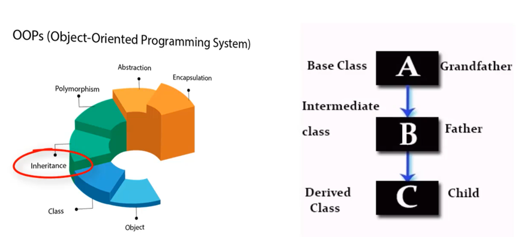

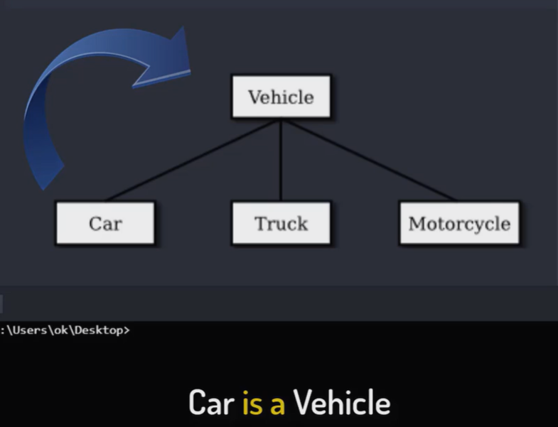

In the programming world, duplicate code is considered **evil**. We should not have multiple copies of the same, or similar, code in different places. **When we fix a bug in one copy and fail to fix the same bug in another copy, we've caused no end of problems for ourselves**.

Moreover, if someone has already written a code, we can reuse without writing it from scratch. Since modules (numpy, Scipy, Pnadas..) are great for fixed functionality, OOP is great for customizing functionality.

**New class functionality = Old class functionality + extra**

Technically, each class we create uses legacy. All Python **classes are subclasses of a special integrated class called an object.**

```python
class MyChild(object):
    # Do stuff here
    pass
```

This is inheritance! **In Python 3, all classes automatically inherit from object if we don't explicitly provide a different superclass.** The `superclasses`, or `parent classes`, in the relationship are the classes that are being inherited from, `object` in this example.

- `MyParent` : class whose functionality is being extended/inherited
- `MyChild` : class that will inherit the functionality and add more

```python
class BankAccount:
    def __init__(self, balance):
        self.balance = balance

    def withdraw(self, amount):
        self.balance -= amount
        return(self.balance)

# Empty class inherited from BankAccount
class SavingsAccount(BankAccount):
    pass
```

**Child class should have all of the parent data**

```python
# Constructor inherited from BankAccount
savings_acct = SavingsAccount(1000)
type(savings_acct)
```

```
__main__.SavingsAccount
```

```python
# Attribute inherited from BankAccount
savings_acct.balance
```

```
1000
```

```python
# Method inherited from BankAccount
savings_acct.withdraw(300)
```

```
700
```

**A SavingsAccount is a BankAccount** (possibly with special features).

```python
savings_acct = SavingsAccount(1000)
isinstance(savings_acct, SavingsAccount)
```

```
True
```

```python
isinstance(savings_acct, BankAccount)
```

```
True
```

### How to Customize Functionality via Inheritance

The code below inherits all instances from `BankAccount` but does not do any thins in saving account.

```python
class BankAccount:
    def __init__(self, balance):
        self.balance = balance

    def withdraw(self, amount):
        self.balance -= amount
        return(self.balance)

# Empty class inherited from BankAccount
class SavingsAccount(BankAccount):
    pass
```

The code below shows `SavingAccount` class that inherits instances from `BankAccount`.

```python
class SavingsAccount(BankAccount):

    # SavingsAccount constructor with an additional parameter
    # inherets balance from BankAccount
    def __init__(self, balance, interest_rate):

        # Parent constructor is called using ClassName.__init__(). self should always be included
        BankAccount.__init__(self, balance) #

        # More functionality is added
        self.interest_rate = interest_rate
```

Explanation of code above:

- Constructor of the parent class is run first by `Parent.__init__(self,...)`
- interest_rate is added as more functionality
- Parent constructors do not need to be called

Now we can make a saving account that inherits balance from `BankAccount` but has interest_rate functionality from `SavingsAccount`.

```python
# Construct the object using the new constructor
account = SavingsAccount(5000, 0.02)
account.interest_rate
```

```
0.02
```

```python
account.balance
```

```
5000
```

Methods can be added to class as usual; the data can be used from both the parent and the child class.

```python
class SavingsAccount(BankAccount):
    def __init__(self, balance, interest_rate):
        # Inherent balance from BankAccount
        BankAccount.__init__(self, balance)
        # interest_rate from SavingsAccount
        self.interest_rate = interest_rate

    # Add new function
    def interest_compute(self, n_periods = 1):
        return self.balance * ( (1 + self.interest_rate) ** n_periods - 1)
```

```python
save_account = SavingsAccount(5000,0.02)
save_account.interest_compute()
```

```
100.00000000000009
```

Now we can make a checking account as below:

```python
class CheckingAccount(BankAccount):
    def __init__(self, balance, limit):
        BankAccount.__init__(self, balance)
        self.limit = limit

    def deposit(self, amount):
        self.balance += amount
        return self.balance

    def withdraw(self, amount, fee=10):
        if fee <= self.limit:
            return BankAccount.withdraw(self, amount - fee)
        else:
            return BankAccount.withdraw(self, amount - self.limit)
```

```python
acct_check = CheckingAccount(1200,limit=15)
# withdraw $200 from CheckingAccount
acct_check.withdraw(15, fee=20)
```

```
1200
```

```python
acct_bank = BankAccount(5000)
# withdraw from BankAccount
acct_bank.withdraw(150)
```

```
4850
```

### Example 1 (Basic inheritance)

How do we apply inheritance in practice? The simplest and most obvious use of inheritance is to **add functionality to an existing class.** Let's start with a contact manager that tracks the names and email addresses of several people (`Contact` class).

```python
from __future__ import annotations
class Contact_info:
    all_contacts: List["Contact"] = []
    def __init__(self, name: str, email: str) -> None:
        self.name = name
        self.email = email
        Contact_info.all_contacts.append(self)
    def __repr__(self) -> str:
        return (
           f"{self.__class__.__name__}("
           f"{self.name!r}, {self.email!r}"
           f")"
       )
```

```python
cont_1 = Contact_info("mehdi", "dusty@example.com")
cont_2 = Contact_info("ali", "ali@itmaybeahack.com")
Contact_info.all_contacts
```

```
[Contact_info('mehdi', 'dusty@example.com'),
 Contact_info('ali', 'ali@itmaybeahack.com')]
```

Two instances of the `Contact` class are created and assigned them to variables `cont_1` and `cont_2`. When we looked at the `Contact_info.all_contacts` class variable, we saw that the list has been updated to track the two objects. But what if some of our contacts are also suppliers that we need to order supplies from?

```python
class Supplier(Contact_info):
    def order(self, order: "Order") -> None:
        print(
            "This item "
            f"'{order}' order to '{self.name}'")
```

```python
s = Supplier("shopper", "hoss@email.com")
```

```python
s.order('pencil')
```

```
This item 'pencil' order to 'shopper'
```

```python
s.all_contacts
```

```
[Contact_info('mehdi', 'dusty@example.com'),
 Contact_info('ali', 'ali@itmaybeahack.com'),
 Supplier('shopper', 'hoss@email.com')]
```

### Example 2 (Overriding and Super)

Inheritance is great for adding new behavior to existing classes, **but what if we want to change behavior?** The `Contact_info` class allows only a name and an email address. But if we want to **add a phone number for our close friends?**, this class cannot do it. We can do this by overriding the **init**() method. **Overriding means altering or replacing a method of the superclass with a new method in the subclass.**

```python
#class Friend(Contact_info):
#    def __init__(self, name: str, email: str, phone: str) -> None:
#        self.name = name
#        self.email = email
#        self.phone = phone

class Friend(Contact_info):
    def __init__(self, name: str, email: str, phone: str) -> None:
        super().__init__(name, email)
        self.phone = phone
```

What we really need is a way to execute the original `__init__()` method on the `Contact_info` class from inside our new class. This is what the `super()` function does; it returns the object as if it was actually an instance of the `parent class`, allowing us to call the parent method directly:

```python
f = Friend("samiar", "samiar@yahoo.com", "7589-1822")
Contact_info.all_contacts
```

```
[Contact_info('mehdi', 'dusty@example.com'),
 Contact_info('ali', 'ali@itmaybeahack.com'),
 Supplier('shopper', 'hoss@email.com'),
 Friend('samiar', 'samiar@yahoo.com')]
```

Another simple example is below:

```python
class Parent:
    def __init__(self, txt):
        self.message = txt

    def printmessage(self):
        print(self.message)

class Child(Parent):
    def __init__(self, txt):
        super().__init__(txt)

x = Child("Hello, and welcome!")

x.printmessage()
```

```
Hello, and welcome!
```

So, the `super()` function is used to give access to methods and properties of a parent.

Another example:

```python
class Mammal:
    def __init__(self, mammalName):
        self.mammalName=mammalName
        print(mammalName, 'is a warm-blooded animal.')

    def leg(self):
        print(self.mammalName, 'has four legs')

class Dog(Mammal):
    def __init__(self,mammalName):
        print('Dog has four legs.')
        super().__init__(mammalName) # supper is more common. If we use super, we should use for entire code.
        # or we can use
        # Mammal.__init__(self,mammalName)

d1 = Dog('cat')
```

```
Dog has four legs.
cat is a warm-blooded animal.
```

```python
d1.leg()
```

```
cat has four legs
```

```python
class Dog(Mammal):
    def __init__(self,mammalName):
        print('Dog has four legs.')
        Mammal.__init__(self,mammalName)

d1 = Dog('cat')
```

```
Dog has four legs.
cat is a warm-blooded animal.
```

# String Representation

## Comparison Objects for Classes

```python
class CustomerInfo:
    def __init__(self, name, balance):
        self.name, self.balance = name, balance

customer1 = CustomerInfo("Mehdi Rezvandehy", 5000)
customer2 = CustomerInfo("Mehdi Rezvandehy", 5000)
customer1==customer2
```

```
False
```

Classes are not equal because Python assigns a chunk of memory for each class when it is created.

```python
print(f'customer1 is {customer1} \ncustomer2 is {customer2}')
```

```
customer1 is <__main__.CustomerInfo object at 0x0000022CC1C4A6D0>
customer2 is <__main__.CustomerInfo object at 0x0000022CC1C4A0D0>
```

However, if we compare two arrays with the same elements, Python gives true.

```python
array1 = np.array([4,3,1,9])
array2 = np.array([4,3,1,9])
array1 == array2
```

```
array([ True,  True,  True,  True])
```

```python
class Customer:
    def __init__(self, id, name, balance):
        self.id, self.name, self.balance = id, name, balance

    # Will be called for == is used
    def __eq__(self, other):
        # Returns True if all attributes match
        return (self.id == other.id) and \
        (self.name == other.name) and \
         (self.balance == other.balance)

     # Will be called for != is used
    def __ne__(self, other):
        # Returns True !=
        return (self.id != other.id) and \
        (self.name != other.name) and \
         (self.balance != other.balance)

    # Will be called for >= is used
    def __ge__(self, other):
        # Returns True >=
        return (self.id >= other.id) and \
         (self.balance >= other.balance)

    # Will be called for <= is used
    def __le__(self, other):
        # Returns True <=
        return (self.id <= other.id) and \
         (self.balance <= other.balance)
```

```python
# Object equality with
customer1 = Customer(178, "Mehdi Rezvandehy",1205)
customer2 = Customer(178, "Mehdi Rezvandehy",1205)
customer1 == customer2
```

```
True
```

- **Other comparison operators**

| **Operator** | **Method** |
| --- | --- |
| != | `__ne__()` |
| == | `__eq__()` |
| >= | `__ge__()` |
| <= | `__le__()` |
| > | `__gt__()` |
| < | `__lt__()` |

```python
# Object equality with
customer1 = Customer(195, "Mehdi Rezvandehy",1209)
customer2 = Customer(178, "Ali Hatami",1205)
customer1 != customer2
```

```
True
```

```python
# Object >=
customer1 = Customer(195, "Mehdi Rezvandehy",1209)
customer2 = Customer(178, "Ali Hatami",1205)
customer1 >= customer2
```

```
True
```

```python
# Object <=
customer1 = Customer(195, "Mehdi Rezvandehy",1209)
customer2 = Customer(198, "Ali Hatami",1305)
customer1 <= customer2
```

```
True
```

- Compare `__str__()` versus `__repr__()`

  *`__str__()` is informal, for end user while `__repr__()` is formal and used for developer

  *`__str__()` is used for string representation while `__repr__()` is used for reproducible representation

  *`__repr__()` is fallback for `print()`

```python
str(np.array([4,5,6]))
```

```
'[4 5 6]'
```

```python
repr(np.array([4,5,6]))
```

```
'array([4, 5, 6])'
```

```python
class Customer_info:
    def __init__(self, name, balance):
        self.name, self.balance = name, balance

    def __str__(self):
        cust_str = f"""
        Customer:
           name: {self.name}
           balance: {self.balance}
        """
        return cust_str

    #def __repr__(self):
    #    cust_str = f"""
    #    Customer:
    #       name: {self.name}
    #       balance: {self.balance}
    #    """
    #    return cust_str
```

```python
cust = Customer_info("Mehdi Rezvandehy", 5000)
# Will implicitly call __str__()
print(cust)
```

```
        Customer:
           name: Mehdi Rezvandehy
           balance: 5000
```

```python
class Customer_info:
    def __init__(self, name, balance):
        self.name, self.balance = name, balance

    #def __str__(self):
    #    cust_str = f"""
    #    Customer:
    #       name: {self.name}
    #       balance: {self.balance}
    #    """
    #    return cust_str

    def __repr__(self):
        cust_str = f"""
        Customer:
           name: {self.name}
           balance: {self.balance}
        """
        return cust_str
```

```python
cust = Customer_info("Mehdi Rezvandehy", 5000)
cust
```

```
        Customer:
           name: Mehdi Rezvandehy
           balance: 5000
```

`__repr__` does not need `print` function while `__str__` needs.

# Exceptions

- Exception prevents the program from terminating when an exception is raised.
- `try` - `except` ... `except`- `finally`
- We can raise an exception by `raise ExceptionNameHere('Error message here')`

```python
def sqrt(value):
    if value <= 0:
        raise ValueError("Invalid Value!")
    return np.sqrt(value)
```

- **Exceptions are classes**
  - standard exceptions are inherited from `BaseException` or `Exception`
- Inherit from `Exception` or one of its subclasses
- Usually an empty class

```python
class BalanceValueError(Exception):
    pass

class Customer:
    def __init__(self, name, balance):
        if balance < 0 :
            raise BalanceValueError("Balance should ne positive!")
        else:
            self.name, self.balance = name, balance
```

```python
customer_bal = Customer("Mehdi Rezvandehy", -20)
```

```
---------------------------------------------------------------------------
BalanceValueError                         Traceback (most recent call last)
~\AppData\Local\Temp\ipykernel_18944\180780449.py in <module>
----> 1 customer_bal = Customer("Mehdi Rezvandehy", -20)

~\AppData\Local\Temp\ipykernel_18944\137691722.py in __init__(self, name, balance)
      5     def __init__(self, name, balance):
      6         if balance < 0 :
----> 7             raise BalanceValueError("Balance should ne positive!")
      8         else:
      9             self.name, self.balance = name, balance

BalanceValueError: Balance should ne positive!
```

- Object is not created since Exception interrupted the constructor.

Now let's look at the tail side of the exception coin. If we encounter an exception situation, how should our code react to or recover from it? We handle exceptions by wrapping any code that might throw one (whether it is exception code itself, or a call to any function or method that may have an exception raised inside it) inside a try...except clause. The most basic syntax looks like this:

```python
def handler() -> None:
    try:
        never_returns()
        print("Never executed")
    except Exception as ex:
        print(f"I caught an exception: {ex!r}")
    print("Executed after the exception")
```

```python
handler()
```

```
I caught an exception: NameError("name 'never_returns' is not defined")
Executed after the exception
```

```python
from typing import Union
def funny_division(divisor: float) -> Union[str, float]:
    try:
        return 100 / divisor
    except ZeroDivisionError:
        return "Zero is not a good idea!"
```

```python
 print(funny_division(0))
```

```
Zero is not a good idea!
```

```python
print(funny_division("hello"))
```

```
---------------------------------------------------------------------------
TypeError                                 Traceback (most recent call last)
~\AppData\Local\Temp\ipykernel_18944\3660904025.py in <module>
----> 1 print(funny_division("hello"))

~\AppData\Local\Temp\ipykernel_18944\2507124677.py in funny_division(divisor)
      2 def funny_division(divisor: float) -> Union[str, float]:
      3     try:
----> 4         return 100 / divisor
      5     except ZeroDivisionError:
      6         return "Zero is not a good idea!"

TypeError: unsupported operand type(s) for /: 'int' and 'str'
```

```python
def funnier_division(divisor: int) -> Union[str, float]:
    try:
        if divisor == 13:
            raise ValueError("13 is an unlucky number")
        return 100 / divisor
    except (ZeroDivisionError, TypeError):
        return "Enter a number other than zero"
```

```python
print(funnier_division(10))
```

```
10.0
```

```python
some_exceptions = [ValueError, TypeError, IndexError, None]
for choice in some_exceptions:
    try:
        print(f"\nRaising {choice}")
        if choice:
            raise choice("An error")
        else:
            print("no exception raised")
    except ValueError:
        print("Caught a ValueError")
    except TypeError:
        print("Caught a TypeError")
    except Exception as e:
        print(f"Caught some other error: {e.__class__.__name__}")
    else:
        print("This code called if there is no exception")
    finally:
        print("This cleanup code is always called")
```

```
Raising <class 'ValueError'>
Caught a ValueError
This cleanup code is always called

Raising <class 'TypeError'>
Caught a TypeError
This cleanup code is always called

Raising <class 'IndexError'>
Caught some other error: IndexError
This cleanup code is always called

Raising None
no exception raised
This code called if there is no exception
This cleanup code is always called
```

**While obscure, the `finally` clause is executed after the `return` statement inside a try clause. While this can be exploited for post-`return` processing, it can also be confusing to folks reading the code.**

# Designing for Inheritance and Polymorphism

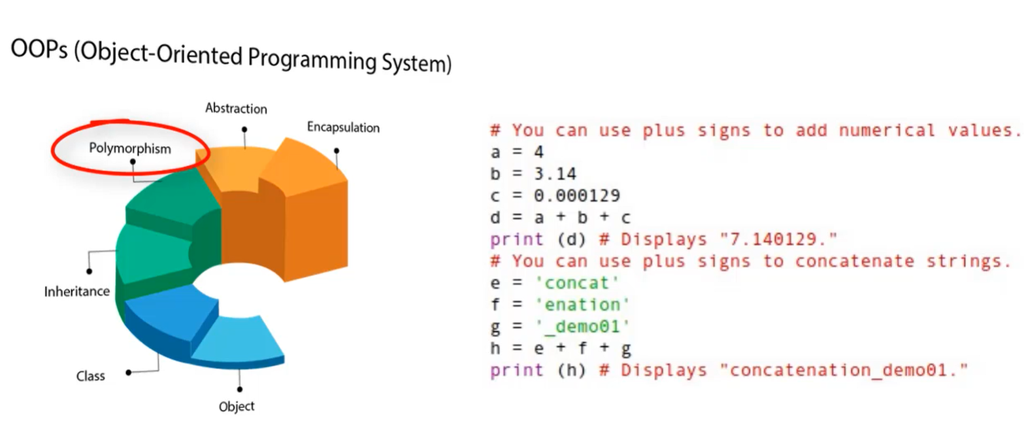

Polymorphism means using a unified interface to operate on objects of different classes. In fact, **different behaviors happen depending on which subclass is being used, without having to explicitly know what the subclass actually is.**

- **Only Interface Matters**

```python
def withdraw_batch(accounts_list,value):
    for accnt in accounts_list:
        accnt.withdraw(value)
```

```python
a, b, c = BankAccount(1000), CheckingAccount(5000,limit=10), SavingsAccount(3000,interest_rate=0.1)
```

```python
a, b, c
```

```
(<__main__.BankAccount at 0x22cc1c768e0>,
 <__main__.CheckingAccount at 0x22cc1c76280>,
 <__main__.SavingsAccount at 0x22cc1c76910>)
```

```python
withdraw_batch([a,b,c],500) # Will use BankAccount.withdraw(), # then CheckingAccount.withdraw(),
# then SavingsAccount.withdraw()
```

- `withdraw_batch()` doesn't need to check the object to know which `withdraw()` to call

## Liskov substitution principle (LSP)

**Liskov substitution principle (LSP):** *Base class should be interchangeable with any of its subclasses without altering any properties of the program.*

**Syntactically:**

- function signatures are compatible
  - arguments, returned values

**Semantically:**

- the state of the object and the program remains consistent
  - subclass method doesn't strengthen input conditions
  - subclass method doesn't weaken output conditions
  - no additional exceptions

```python
# Compare withdraw of BankAccount with withdraw of CheckingAccount
class BankAccount:
    def __init__(self, balance):
        self.balance = balance

    def withdraw(self, amount):
        self.balance -= amount
        return(self.balance)

##############################################

class CheckingAccount(BankAccount):
    def __init__(self, balance, limit):
        BankAccount.__init__(self, balance)
        self.limit = limit

    def deposit(self, amount):
        self.balance += amount
        return self.balance

    def withdraw(self, amount, fee=10):
        if fee <= self.limit:
            return BankAccount.withdraw(self, amount - fee)
        else:
            return BankAccount.withdraw(self, amount - self.limit)
```

**Violating LSP by Syntactic incompatibility**

**Violating LSP by Subclass strengthening input conditions**

- `BankAccount.withdraw()` accepts any amount, but `CheckingAccount.withdraw()` assumes that the amount is limited

**Other Violating LSP**

- Changing additional attributes in subclass's method
- Throwing additional exceptions in subclass's method

## More details to LSP

The Liskov substitution principle states that a **child class must be substitutable for its parent class.** Liskov substitution principle aims to ensure that the child class can assume the place of its parent class without causing any errors. The example below shows meeting LSP retrieved from [here](https://www.pythontutorial.net/python-oop/python-liskov-substitution-principle/#:~:text=The%20Liskov%20substitution%20principle%20states,class%20without%20causing%20any%20errors).

```python
from abc import ABC, abstractmethod


class Notification(ABC):
    @abstractmethod
    def notify(self, message):
        pass


class Email(Notification):
    def __init__(self, email):
        self.email = email

    def notify(self, message):
        print(f'Send "{message}" to {self.email}')


class SMS(Notification):
    def __init__(self, phone):
        self.phone = phone

    def notify(self, message):
        print(f'Send "{message}" to {self.phone}')


class Contact:
    def __init__(self, name, email, phone):
        self.name = name
        self.email = email
        self.phone = phone


class NotificationManager:
    def __init__(self, notification):
        self.notification = notification

    def send(self, message):
        self.notification.notify(message)


if __name__ == '__main__':
    contact = Contact('John Doe', 'john@test.com', '(408)-888-9999')

    sms_notification = SMS(contact.phone)
    email_notification = Email(contact.email)

    notification_manager = NotificationManager(sms_notification)
    notification_manager.send('Hello John')

    notification_manager.notification = email_notification
    notification_manager.send('Hi John')
```

```
Send "Hello John" to (408)-888-9999
Send "Hi John" to john@test.com
```

`notify` method in parent class `Notification` is the same as the child classes `Email` and `SMS`.

Another example, imagine a program that plays audio files. However, the process of decompressing and extracting an audio file is very different for different types of files. While `.wav` files are stored uncompressed, `.mp3, .wma,` and `.ogg` files all utilize totally different compression algorithms.

We can use inheritance with polymorphism to simplify the design. Each type of file can be represented by a different subclass of `AudioFile`, for example, `WavFile` and `MP3File`. Each of these would have a `play()` method that would be implemented differently for each file to ensure that the correct extraction procedure is followed. The media player object would never need to know which subclass of `AudioFile` it is referring to; it just calls `play()` and **polymorphically lets the object take care of the actual details of playing.** Let's look at a quick skeleton showing how this might work:

```python
from pathlib import Path
class AudioFile:
    ext: str
    def __init__(self, filepath: Path) -> None:
        if not filepath.suffix == self.ext:
            raise ValueError("Invalid file format")
        self.filepath = filepath
class MP3File(AudioFile):
    ext = ".mp3"
    def play(self) -> None:
        print(f"playing {self.filepath} as mp3")
class WavFile(AudioFile):
    ext = ".wav"
    def play(self) -> None:
        print(f"playing {self.filepath} as wav")
class OggFile(AudioFile):
    ext = ".ogg"
    def play(self) -> None:
        print(f"playing {self.filepath} as ogg")
```

All audio files check to ensure that a valid extension was given upon initialization. If the filename doesn't end with the correct name, it raises an exception.

The `__init__()` method in the parent class is able to access the `ext` class variable from different subclasses. **That's polymorphism at work.**

In addition, each subclass of `AudioFile` implements `play()` in a different way. **This is also polymorphism in action.** The media player can use the exact same code to play a file, no matter what type it is; it doesn't care what subclass of AudioFile it is looking at.

Retrieved from [Lott and Phillips,Python Object-Oriented Programming](https://learning.oreilly.com/library/view/python-object-oriented-programming/9781801077262/)

```python
p_1 = MP3File(Path("you are my sunshine.mp3"))
p_1.play()
p_2 = WavFile(Path("my only sunshine.wav"))
p_2.play()
p_3 = WavFile(Path("my only sunshine.wrd"))
```

```
playing you are my sunshine.mp3 as mp3
playing my only sunshine.wav as wav
```

```
---------------------------------------------------------------------------
ValueError                                Traceback (most recent call last)
~\AppData\Local\Temp\ipykernel_18944\2042668637.py in <module>
      3 p_2 = WavFile(Path("my only sunshine.wav"))
      4 p_2.play()
----> 5 p_3 = WavFile(Path("my only sunshine.wrd"))

~\AppData\Local\Temp\ipykernel_18944\1497370230.py in __init__(self, filepath)
      4     def __init__(self, filepath: Path) -> None:
      5         if not filepath.suffix == self.ext:
----> 6             raise ValueError("Invalid file format")
      7         self.filepath = filepath
      8 class MP3File(AudioFile):

ValueError: Invalid file format
```

```python
filepath=Path("you are my sunshine.mp3")
filepath.suffix
```

```
'.mp3'
```

# Naming Convention

- we are all adults. All class data is public
- However, we can use restricting access using 1- naming conventions, 2- use `@property`, 3- Overriding `__getattr__()` and `__setattr__()`

## Naming Convention for Internal Attributes

`obj._attr_name`, `obj._func_name()`

- when name start with a single `_`, it is "internal".
- It should not be part of public API.
- If you are a class user, you **should NOT touch this**.
- If you are a class developer: you can use it for helper functions, implementation details ...

  `df._var1_to_mean`(attribute), `measure._m_to_in()`(function)

## Encapsulation, Naming convention for pseudo-private attributes

`obj.__attr_name`, `obj.__func_name()`

- when name start with a double `__` but not end with, it is "private".
- There is no inheritance
- If you are a class user, you **should NOT touch this**
- If you are a class developer: you can use it for helper functions, implementation details ...

  `df.__var1_to_mean`(attribute), `measure.__m_to_in()`(function)

Trailing and leading `__` are only used for built-in Python methods (`__int__()`, `__repr__()`)

Here is an example of **encapsulation**:

```python
class Speed:
    def __init__(self):
        self.speed=10
        self.__new_speed=80

s=Speed()
print(s.speed)
print(s.__new_speed)
```

```
10
```

```
---------------------------------------------------------------------------
AttributeError                            Traceback (most recent call last)
~\AppData\Local\Temp\ipykernel_18944\3665847376.py in <module>
      6 s=Speed()
      7 print(s.speed)
----> 8 print(s.__new_speed)

AttributeError: 'Speed' object has no attribute '__new_speed'
```

We do not have access to private value but we can modify it so this is a big problem. To resolve this we use getter and setter.

```python
class Speed:
    def __init__(self):
        self.speed=10
        self.__new_speed=80

    # this is a getter (we are getting a private value)
    def get_new_speed(self):
        return self.__new_speed

    # this is a setter (we are changing or modifying a private value)
    def set_new_speed(self, new_speed):
        self.__new_speed=new_speed

s=Speed()
print(s.speed)
print(s.get_new_speed())

s.set_new_speed(100)

print(s.get_new_speed())
```

```
10
80
100
```

Here is another example for private function:

```python
class Example:
    def __init__(self):
        self.x=10
        self._y=50
        self.__z=100

    def public_method(self):
        print(self.x)
        print(self._y)
        print(self.__z)

    def __private_method(self):
        print("Inside Private Method")


s=Example()
print(s.x)
print(s._y)
print(s.__z)
```

```
10
50
```

```
---------------------------------------------------------------------------
AttributeError                            Traceback (most recent call last)
~\AppData\Local\Temp\ipykernel_18944\3519030824.py in <module>
     17 print(s.x)
     18 print(s._y)
---> 19 print(s.__z)

AttributeError: 'Example' object has no attribute '__z'
```

```python
print(s.public_method())
print(s.__private_method())
```

```
10
50
100
None
```

```
---------------------------------------------------------------------------
AttributeError                            Traceback (most recent call last)
~\AppData\Local\Temp\ipykernel_18944\3341620232.py in <module>
      1 print(s.public_method())
----> 2 print(s.__private_method())

AttributeError: 'Example' object has no attribute '__private_method'
```

```python
class Example:
    def __init__(self):
        self.x=10
        self._y=50
        self.__z=100

    def public_method(self):
        print(self.x)
        print(self._y)
        print(self.__z)
        self.__private_method()

    def __private_method(self):
        print("Inside Private Method")


s=Example()
s.public_method()
```

```
10
50
100
Inside Private Method
```

Here are more details:

```python
class Employee_info:
    def __init__(self,name,salary):
        self.name, self.salary=name,salary
        #
    def name(self,name):
        self.name=name
        #
    def salary(self, salary):
        self.salary= salary
        #
    def _raise(self, amount):
        self.salary=self.salary + amount

em_info=Employee_info('mehdi rezvandehy',3500)
print(em_info.name)
em_info.salary=em_info.salary+6500
print(em_info.salary)
```

```
mehdi rezvandehy
10000
```

We can add and subtract any value to a attribute. This might be problem because attribute might be string or the final result may not make sense (for example negative salary). The question is how to protect an attribute.

In Python, `property()` is a built-in function that creates and returns a `property` object. Let's say that this class is part of your program. You are modeling a house with a House class (at the moment, the class only has a price instance attribute defined):

```python
class House:
    def __init__(self, price):
        self.price = price
```

**This instance attribute is public because its name doesn't have a leading underscore.** Since the attribute is currently public, it is very likely that you and other developers in your team **accessed and modified** the attribute directly in other parts of the program using dot notation, like this:

obj.price # Access value

obj.price = 40000 # Modify value

So far everything is working great, right? **But let's say that you are asked to make this attribute protected (non-public) and validate the new value before assigning it.** Specifically, you need to check if the value is a positive float. How would you do that? Let's see.

At this point, if you decide to add `getters` and `setters`, you and your team will probably panic?. This is because each line of code that accesses or modifies the value of the attribute will have to be modified to call the `getter` or `setter`, respectively. Otherwise, the code will break ⚠️.

obj.get_price() # Changed from obj.price

obj.set_price(40000) # Changed from obj.price = 40000

**But... Properties come to the rescue!** With @property, you and your team will not need to modify any of those lines because you will able to add `getters` and `setters` "behind the scenes" without affecting the syntax that you used to access or modify the attribute when it was public.

If you decide to use `@property`, your class will look like the example below:

```python
class House:

    def __init__(self, price):
        self._price = price

    @property # (or getter)
    def price(self):
        return self._price

    @price.setter
    def price(self, new_price):
        if new_price > 0 and isinstance(new_price, float):
            self._price = new_price
        else:
            print("Please enter a valid price")

    @price.deleter
    def price(self):
        del self._price
```

Specifically, we can define three methods for a property:

- A `getter` - to access the value of the attribute.
- A `setter` - to set the value of the attribute.
- A `deleter` - to delete the instance attribute.

**Price is now "Protected"**

Please note that the *price* attribute is now considered "protected" because we added a leading underscore to its name in `self._price`:

`self._price = price`

**In Python, by convention, when you add a leading underscore to a name, you are telling other developers that it should not be accessed or modified directly outside of the class. It should only be accessed through intermediaries (getters and setters) if they are available.**

## Getter

Here we have the getter method:

```python
@property
def price(self):
    return self._price
```

Notice the syntax:

- `@property` - Used to indicate that we are going to define a property. Notice how this immediately improves readability because we can clearly see the purpose of this method.
- `def price(self)` - The header. Notice how the `getter` is named exactly like the property that we are defining: `price`. This is the name that we will use to access and modify the attribute outside of the class. The method only takes one formal parameter, `self`, which is a reference to the instance.
- return `self._price` - This line is exactly what you would expect in a regular `getter`. **The value of the protected attribute is returned.**

```python
class House:
    def __init__(self, price):
        self._price = price

    @property # (or getter)
    def price(self):
        return self._price

house = House(50000.0) # Create instance
house.price            # Access value
50000.0
```

```
50000.0
```

The value for price cannot be changed because of being considered as "protected" due to having a leading underscore to its name

## Setter

```python
@price.setter
def price(self, new_price):
    if new_price > 0 and isinstance(new_price, float):
        self._price = new_price
    else:
        print("Please enter a valid price")
```

- `@price.setter` - Used to indicate that this is the setter method for the price property. Notice that we are not using `@property.setter`, we are using `@price.setter`. The name of the property is included before `.setter`.
- `def price(self, new_price):` - The header and the list of parameters. Notice how the name of the property is used as the name of the setter. We also have a second formal parameter (`new_price`), which is the new value that will be assigned to the price attribute (if it is valid).
- Finally, we have the body of the setter where we **validate** the argument to check if it is a positive float and then, if the argument is valid, we update the value of the attribute. If the value is not valid, a descriptive message is printed. You can choose how to handle invalid values according the needs of your program.

```python
isinstance(568.0, float)
```

```
True
```

```python
class House:
    def __init__(self, price):
        self._price = price

    @property # (or getter)
    def price(self):
        return self._price

    @price.setter
    def price(self, new_price):
        if new_price > 0 and isinstance(new_price, float):
            self._price = new_price
        else:
            print("Please enter a valid price")
```

```python
house = House(40000.0)  # Create instance
house.price = 35000.0   # Update value
house.price             # Access value
```

```
35000.0
```

```python
house = House(50000.0)
house.price = -50
```

```
Please enter a valid price
```

This proves that the setter method is working as an intermediary. It is being called "behind the scenes" when we try to update the value, so the descriptive message is displayed when the value is not valid.

## Deleter

```python
@price.deleter
def price(self):
    del self._price
```

`@price.deleter` - Used to indicate that this is the deleter method for the price property. Notice that this line is very similar to `@price.setter`, but now we are defining the deleter method, so we write `@price.deleter`.

`def price(self):` - The header. This method only has one formal parameter defined, self.

`del self._price` - The body, where we delete the instance attribute.

This is an example of the use of the deleter method with `@property`:

```python
class House:

    def __init__(self, price):
        self._price = price

    @property # (or getter)
    def price(self):
        return self._price

    @price.setter
    def price(self, new_price):
        if new_price > 0 and isinstance(new_price, float):
            self._price = new_price
        else:
            print("Please enter a valid price")

    @price.deleter
    def price(self):
        del self._price
```

```python
# Create instance
house = House(50000.0)

# The instance attribute exists
house.price
```

```
50000.0
```

```python
# Delete the instance attribute
del house.price

# The instance attribute doesn't exist
house.price
```

```
---------------------------------------------------------------------------
AttributeError                            Traceback (most recent call last)
~\AppData\Local\Temp\ipykernel_18944\1766094459.py in <module>
      3
      4 # The instance attribute doesn't exist
----> 5 house.price

~\AppData\Local\Temp\ipykernel_18944\3631519707.py in price(self)
      6     @property # (or getter)
      7     def price(self):
----> 8         return self._price
      9
     10     @price.setter

AttributeError: 'House' object has no attribute '_price'
```

# Composition and Aggregation

Sometimes a class can be inherited to another class since the relationships is not **parent-child**, for example **Books** and **Library** are very close but we cannot say book is a library! Another example is salary and employee with very high relationship. In this case, we cannot use inheritance since they do not have that relationship. **Composition** (strong association) is used when two classes are highly depended to each other. Salary is part of Employee content is part of container.

```python
class Salary:
    def __init__(self, pay, reward):
        self.pay  = pay
        self.reward =  reward

    def annual_salary(self):
        return (self.pay*12)+self.reward

class Employee:
    def __init__(self, name, position, pay, reward):
        self.name = name
        self.position = position
        self.final_salary = Salary(pay, reward)


    def final_salary_m(self):
        return self.final_salary.annual_salary()


emp = Employee("Mehdi","Data Sientist", 10000,1000)
print (emp.final_salary_m())
```

```
121000
```

Another important parameter is **aggregation** (weak association) when there is a has relationship. For example, Bank has a Employee, Library has a book.

```python
class Salary:
    def __init__(self, pay, reward):
        self.pay  = pay
        self.reward =  reward

    def annual_salary(self):
        return (self.pay*12)+self.reward

class Employee:
    def __init__(self, name, position, sal):
        self.name = name
        self.position = position
        self.final_salary = sal


    def final_salary_m(self):
        return self.final_salary.annual_salary()

sal = Salary (100000,10000)
emp = Employee("Mehdi","Data Sientist", sal)
print (emp.final_salary_m())
```

```
1210000
```

# Abstract Class

Sometimes we do not want to create an object from our parent class, we just want to allow only creating object from subclass. In this case, abstract class can be used.

```python
from abc import ABC, abstractmethod

class Shape(ABC):
    @abstractmethod # decorator
    def area(self):
        pass
    @abstractmethod # decorator
    def perimeter(self):
        pass

class Square(Shape):
    def __init__(self,side):
        self.__side= side

shape_obj = Shape()
square_obj = Square(10)
```

```
---------------------------------------------------------------------------
TypeError                                 Traceback (most recent call last)
~\AppData\Local\Temp\ipykernel_18944\649407628.py in <module>
     13         self.__side= side
     14
---> 15 shape_obj = Shape()
     16 square_obj = Square(10)

TypeError: Can't instantiate abstract class Shape with abstract methods area, perimeter
```

```python
class Shape(ABC):
    @abstractmethod # decorator
    def area(self):
        pass
    @abstractmethod # decorator
    def perimeter(self):
        pass

class Square(Shape):
    def __init__(self,side):
        self.__side = side

    def area(self):
        return self.__side * self.__side

#    def perimeter(self):
#        return 4*self.__side

shape_obj = Square(10)
print(shape_obj.area())
```

```
---------------------------------------------------------------------------
TypeError                                 Traceback (most recent call last)
~\AppData\Local\Temp\ipykernel_18944\739178187.py in <module>
     17 #        return 4*self.__side
     18
---> 19 shape_obj = Square(10)
     20 print(shape_obj.area())

TypeError: Can't instantiate abstract class Square with abstract method perimeter
```

```python
class Shape(ABC):
    @abstractmethod # decorator
    def area(self):
        pass
    @abstractmethod # decorator
    def perimeter(self):
        pass

class Square(Shape):
    def __init__(self,side):
        self.__side = side

    def area(self):
        return self.__side * self.__side

    def perimeter(self):
        return 4*self.__side

shape_obj = Square(10)
print(shape_obj.area())
```

```
100
```

# `__name__ == __main__`

If the python interpreter is running source file as the main program, it sets the special `__name__` variable to have a value `“__main__”`. If this file is being imported from another module, `__name__` will be set to the module’s name. Module’s name is available as value to `__name__` global variable.

```python
# Python program to execute
# main directly
print ("Always executed")

if __name__ == "__main__":
    print ("Executed when invoked directly")
else:
    print ("Executed when imported")
```

```
Always executed
Executed when invoked directly
```

```python
# Python function
def my_function():
    print ("I am inside function")

# We can test function by calling it.
my_function()
```

```
I am inside function
```

```python
if __name__ == "__main__":
    my_function()

import myscript

myscript.my_function()
```

```
I am inside function
I am inside module
```